# dtPosidonia: a model of Posidonia

Karline Soetaert, Quinten Mudde, Joran de Gang, and Marilaure Gregoire

29-november-2017

The *dtPosidonia* package models dynamics of Posidonia populations.

For now the package contains the following functions:

```r
ls("package:dtPosidonia")
```

```
## [1] "Posidonia_get_forcings" "Posidonia_get_parms"    "Posidonia_get_states"
## [4] "Posidonia_get_vars"     "Posidonia_run"          "forcs_calvi"
## [7] "obs_calvi"
```

# Function Posidonia_run

Function *Posidonia_run* runs the dynamic Posidonia model.

```r
args(Posidonia_run)
```

```
## function (parms = list(), times = 0:365, yini = NULL, f_Temperature = 20,
##     f_Light = 100, f_Daylength = 12, f_Wind = 1, f_Piston = 1,
##     f_SatO2 = 0.36)
## NULL
```

# Functions to obtain model settings

```r
args(Posidonia_get_parms)
```

```
## function (out, as.vector = FALSE, which = NULL)
## NULL
```

```r
args(Posidonia_get_vars)
```

```
## function (out, as.vector = FALSE, which = NULL)
## NULL
```

```r
Parms  <- Posidonia_get_parms(as.vector = TRUE)
States <- Posidonia_get_states(as.vector = TRUE)
```

```r
extract_data <- function(data,  # data.frame with 3 columns (variable, day, value)
                         name){

  data.extract   <- subset(data,
                           subset = variable == name,
                           select = c(day, value))

  colnames(data.extract)[2] <- name

  return(data.extract)
}
```

```r
data.oxygen   <- extract_data(obs_calvi, "OXYGEN")
data.leaves   <- extract_data(obs_calvi, "LEAVES")
data.roots    <- extract_data(obs_calvi, "ROOTS")
data.rhizomes <- extract_data(obs_calvi, "RHIZOMES")
```

```r
data.temp     <- extract_data(forcs_calvi, "f_Temperature")
data.light    <- extract_data(forcs_calvi, "f_Light")
data.wind     <- extract_data(forcs_calvi, "f_Wind")

funtemp       <- approxfun(x = data.temp$day,
                           y = data.temp$f_Temperature, rule = 2)
funlight      <- approxfun(x = data.light$day,
                           y = data.light$f_Light,      rule = 2)
funwind       <- approxfun(x = data.wind$day,
                           y = data.wind$f_Wind,        rule = 2)

Day   <- trunc(data.wind$day)
Wind  <- aggregate(x   = data.wind$f_Wind,
                   by  = list(day = Day),
                   FUN = mean)
fwind <- approxfun(x    = Wind$day,
                   y    = Wind$x,
                   rule = 2)

# Estimated with marelac functions
Time <- seq(from = 0., to = 365, by = 1)

ftemp     <- cbind(Time, funtemp (Time))
flight    <- cbind(Time, funlight(Time))
fwind     <- cbind(Time, funwind (Time))

funpiston  <- approxfun(x = Time,
                        y = gas_transfer(t   = ftemp[,2],
                                         u10 = fwind[,2],
                                         species = "O2",
                                         method = "Nightingale")*86400)  # m/d
funSatox   <- approxfun(x = Time,
                        y = gas_O2sat(S = Parms["salinity"],
                                      t = ftemp[,2]) / molweight("O2")) #in mol/m3
fpiston    <- cbind(Time, funpiston(Time))
fSatox     <- cbind(Time, funSatox(Time))
```

```r
times  <- seq(from = 0, to = 365, by = 1)

 P    <- Posidonia_run(times = times, yini = States, f_Temperature = ftemp,
                       f_Light = flight, f_Wind = fwind, f_Piston = fpiston,
                       f_SatO2 = fSatox)


Parms2 <- list(maxPhotosynthesis= 0.05)   # /D

 P2    <- Posidonia_run(parms = Parms2,
                       times = times, yini = States, f_Temperature = ftemp,
                       f_Light = flight, f_Wind = fwind, f_Piston = fpiston,
                       f_SatO2 = fSatox)

Parms3 <- list(maxPhotosynthesis= 0.005)   # /D
 P3    <- Posidonia_run(parms = Parms3,
                       times = times, yini = States, f_Temperature = ftemp,
                       f_Light = flight, f_Wind = fwind, f_Piston = fpiston,
                       f_SatO2 = fSatox)
```

## Plotting output variables and state variables

The model solution is a matrix with values of the state variables and the output variables, at each time step. We can select *which* variables we want to be displayed and how the figures have to be arranged (*mfrow = c(4, 3)* means 4 rows and 3 columns)

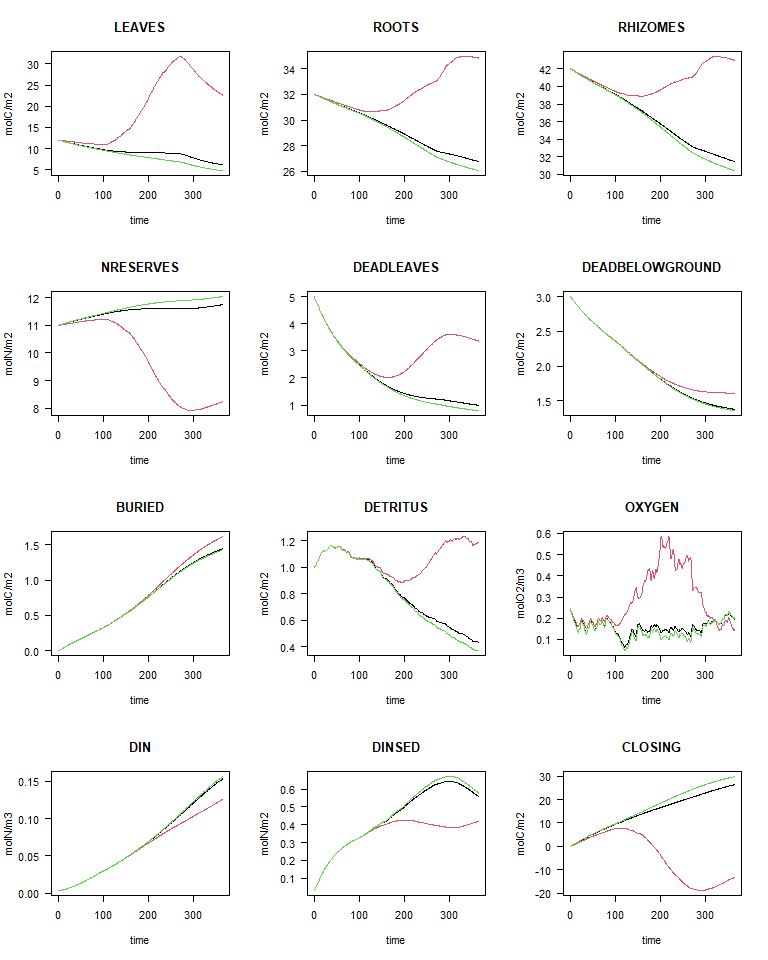

```r
plot(P, P2, P3, mfrow = c(4, 3), which = 1:12)
```

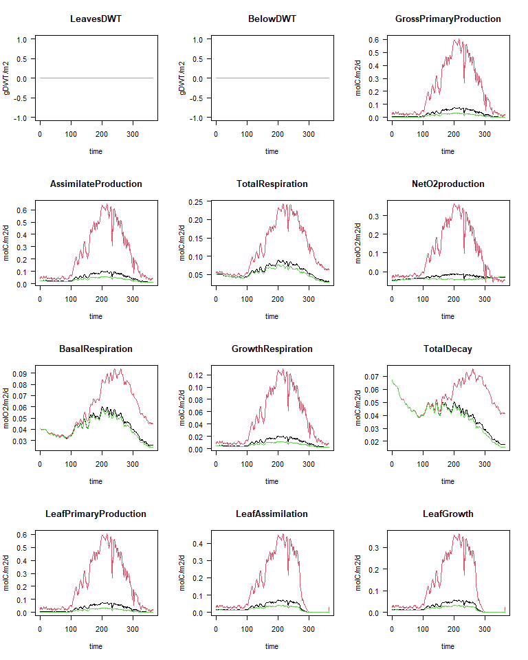

```r
plot(P, P2, P3, mfrow = c(4, 3), which = 13:24)
```

## Comparison with Observations

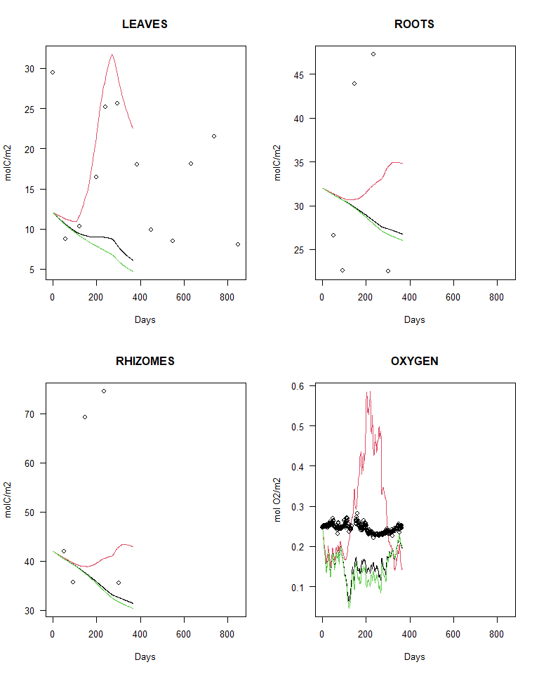

```r
par  (mfrow = c(2,2))
plot(P, P2, P3, obs = obs_calvi,
     which = c("LEAVES", "ROOTS", "RHIZOMES", "OXYGEN"),
     xlab = "Days", ylab = c("molC/m2", "molC/m2", "molC/m2", "mol O2/m2"))
```

## Diagnostic computation. Compute the Annual mean flow

One of the aims of a model like this is to estimate the flows of carbon or nutrients between the various organs. Here we show how to do this for carbon. It is easiest to make a data.frame from the output matrix first, as then we can easily extract the data by their name.

```r
Q  <- as.data.frame(P)

## CARBON budget
F.DICtoLEAVES               <- mean(Q$GrossPrimaryProduction)-mean(Q$LeafTotalRespiration)
F.LEAVEStoDETRITUS          <- mean(Q$LeafBreaking)
F.LEAVEStoDEADLEAVES        <- mean(Q$LeafMortality)
F.ASSIMILATEStoLEAVES       <- mean(Q$LeafAssimilation)
F.LEAVEStoASSIMILATES       <- mean(Q$GrossPrimaryProduction)+mean(Q$LeafNetReallocation)
F.DEADLEAVEStoDETRITUS      <- mean(Q$DeadLeafAbscission)+mean(Q$DeadLeafBreaking)
F.DEADLEAVEStoDIC           <- mean(Q$DeadLeafDecay)
F.RHIZOMEtoDIC              <- mean(Q$RhizomeTotalRespiration)
F.ASSIMILATEStoRHIZOMES     <- mean(Q$RhizomeAssimilation)
F.RHIZOMEStoASSIMILATES     <- mean(Q$RhizomeMobilisation)
F.RHIZOMEStoDEADBELOWGROUND <- mean(Q$RhizomeMortality)
F.ROOTtoDIC                 <- mean(Q$RootTotalRespiration)
F.ASSIMILATEStoROOTS        <- mean(Q$RootAssimilation)
F.ROOTtoDEADBELOWGROUND     <- mean(Q$RootMortality)
F.DEADBELOWGROUNDtoDIC      <- mean(Q$BelowgroundDecay)
F.DETRITUStoDIC             <- mean(Q$DetritusDecay)
F.DETRITUStoEXPORT          <- mean(Q$DetritusExport)

##Others
AnnualGPP                    <- mean(Q$GrossPrimaryProduction)
AnnualNPP                    <- mean(Q$NetO2production)
AnnualTotalRespiration       <- mean(Q$TotalRespiration)
```

## Plot the Foodweb and check the budget

Using a plotting function in the package *diagram*, we can now plot the flows between the various organs.

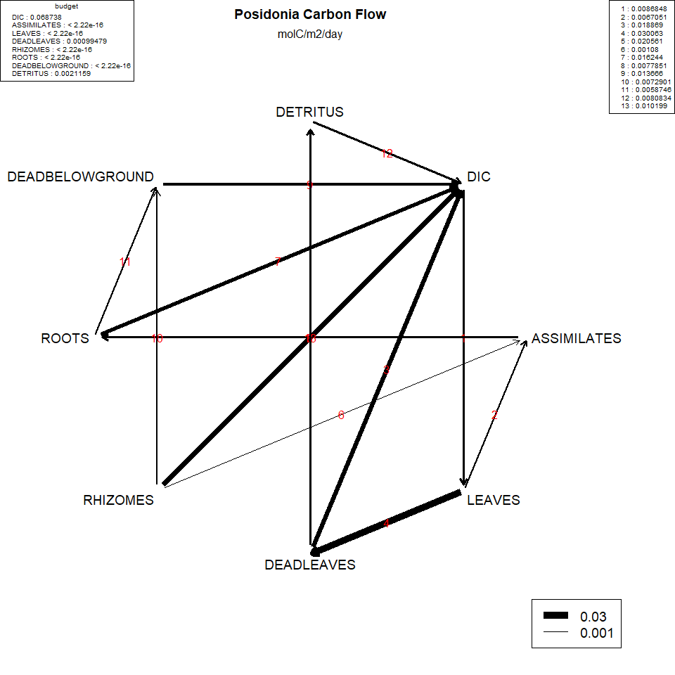

Et voila!

# References

Package to solve the differential equations

Karline Soetaert, Thomas Petzoldt, R. Woodrow Setzer (2010). Solving Differential Equations in R: Package deSolve. Journal of Statistical Software, 33(9), 1–25. URL http://www.jstatsoft.org/v33/i09/ DOI 10.18637/jss.v033.i09.

Package to estimate the oxygen saturation

Karline Soetaert, and Thomas Petzoldt (2017). marelac: Tools for Aquatic Sciences. R package version 2.1.6